# WEEk 6

## Plot Scattered plot to visualize the data

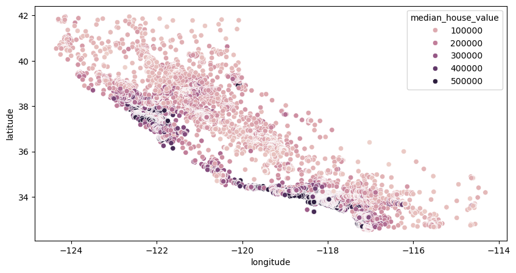

```python
import matplotlib.pyplot as plt
import seaborn as sns

plt.figure(figsize=(10,5))
sns.scatterplot(data = home_data, x = 'longitude', y = 'latitude', hue = 'median_house_value')
plt.show()
```

## Split train/ Test and Normalize Data

```python
from sklearn.model_selection import train_test_split
from sklearn import preprocessing
X_train, X_test, y_train, y_test = train_test_split(home_data[['latitude', 'longitude']], home_data[['median_house_value']], test_size=0.33, random_state=0)

X_train_norm = preprocessing.normalize(X_train)
X_test_norm = preprocessing.normalize(X_test)
```

## fit the data to the k-means model and plot the clusters into scattered plot

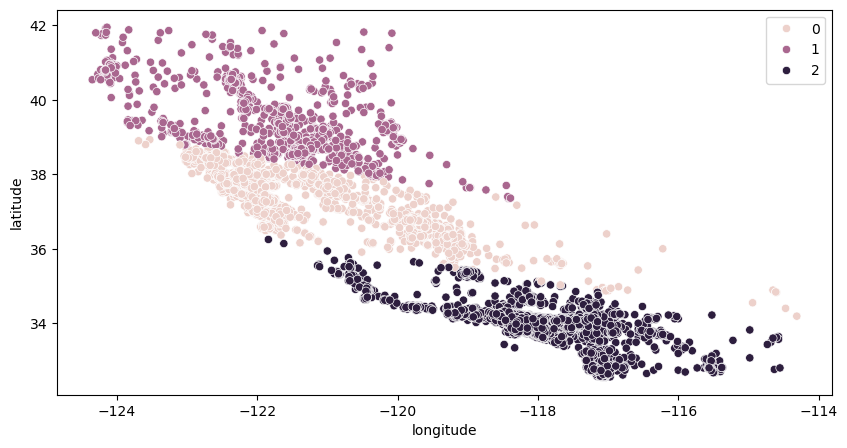

```python
from sklearn.cluster import KMeans
kmeans = KMeans(n_clusters = 3, random_state = 0, n_init='auto')
kmeans.fit(X_train_norm)

plt.figure(figsize=(10,5))
sns.scatterplot(data = X_train, x = 'longitude', y = 'latitude', hue = kmeans.labels_)
plt.show()
```

```python
from sklearn.metrics import silhouette_score
sil_score=silhouette_score(X_train_norm, kmeans.labels_, metric='euclidean')
print (sil_score)
```

```
0.7499371920703547
```

## Deep Learning

Design simple Artifical neural network

- 1 input
- 1 hidden layer
- 1 output layer

```python
import numpy as np
import matplotlib.pyplot as plt

class NeuralNetwork:
    def __init__(self, input_neurons, hidden_neurons, output_neurons, learning_rate):
        # Ini-tialize network parameters
        self.input_neurons = input_neurons
        self.hidden_neurons = hidden_neurons
        self.output_neurons = output_neurons
        self.learning_rate = learning_rate

        # Random initialization of weights and biases
        np.random.seed(42)
        self.w1 = np.random.randn(input_neurons, hidden_neurons)
        self.b1 = np.random.randn(hidden_neurons)
        self.w2 = np.random.randn(hidden_neurons, output_neurons)
        self.b2 = np.random.randn(output_neurons)
    def sigmoid(self, x):
        return 1 / (1 + np.exp(-x))

    def sigmoid_derivative(self, x):
        return x * (1 - x)

    def forward_pass(self, x):
        self.z1 = np.dot(x, self.w1) + self.b1 # w1.x +b
        self.a1 =self.sigmoid(self.z1) # apply the sigmoid activation function

        self.z2 = np.dot(self.a1, self.w2) + self.b2
        self.output = self.sigmoid(self.z2) #apply sigmoid activation function

        return self.output
    def compute_loss(self, y_pred, y_true):
        return np.mean((y_pred - y_true) ** 2)

    def backpropagate(self, x, y_true, y_pred):
        error_output = y_pred - y_true
        d_output = error_output * self.sigmoid_derivative(y_pred)

        error_hidden = d_output.dot(self.w2.T)
        d_hidden = error_hidden * self.sigmoid_derivative(self.a1)

        self.w2 -= self.a1.T.dot(d_output) * self.learning_rate
        self.b2 -= np.sum(d_output, axis=0) * self.learning_rate

        self.w1 -= x.T.dot(d_hidden) * self.learning_rate
        self.b1 -= np.sum(d_hidden, axis=0) * self.learning_rate

    def train(self, X, y, epochs=5000):
        for epoch in range(epochs):
            y_pred = self.forward_pass(X)

            # Compute loss
            loss = self.compute_loss(y_pred, y)

            # Backpropagation and weights update
            self.backpropagate(X, y, y_pred)

            if epoch % 1000 == 0:
                print(self.w1,self.w2)
                print(f"Epoch {epoch}, loss: {loss:.4f}")

    def predict(self, X):
        return self.forward_pass(X)
```

## Train model for predicting the house price by sq.feet

```
[[0.49671415]] [[147.32029028]]
Epoch 0, loss: 86783878265.4901
[[0.49671415]] [[147.32029028]]
Epoch 1000, loss: 86783823796.3995
[[0.49671415]] [[147.32029028]]
Epoch 2000, loss: 86783823796.3995
[[0.49671415]] [[147.32029028]]
Epoch 3000, loss: 86783823796.3995
[[0.49671415]] [[147.32029028]]
Epoch 4000, loss: 86783823796.3995
[[0.49671415]] [[147.32029028]]
Epoch 5000, loss: 86783823796.3995
[[0.49671415]] [[147.32029028]]
Epoch 6000, loss: 86783823796.3995
[[0.49671415]] [[147.32029028]]
Epoch 7000, loss: 86783823796.3995
[[0.49671415]] [[147.32029028]]
Epoch 8000, loss: 86783823796.3995
[[0.49671415]] [[147.32029028]]
Epoch 9000, loss: 86783823796.3995
[[0.49671415]] [[147.32029028]]
Epoch 10000, loss: 86783823796.3995
[[0.49671415]] [[147.32029028]]
Epoch 11000, loss: 86783823796.3995
[[0.49671415]] [[147.32029028]]
Epoch 12000, loss: 86783823796.3995
[[0.49671415]] [[147.32029028]]
Epoch 13000, loss: 86783823796.3995
[[0.49671415]] [[147.32029028]]
Epoch 14000, loss: 86783823796.3995
[[0.49671415]] [[147.32029028]]
Epoch 15000, loss: 86783823796.3995
[[0.49671415]] [[147.32029028]]
Epoch 16000, loss: 86783823796.3995
[[0.49671415]] [[147.32029028]]
Epoch 17000, loss: 86783823796.3995
[[0.49671415]] [[147.32029028]]
Epoch 18000, loss: 86783823796.3995
[[0.49671415]] [[147.32029028]]
Epoch 19000, loss: 86783823796.3995
```

[output cut: 45 more lines]

```
Epoch 42000, loss: 86783823796.3995
[[0.49671415]] [[147.32029028]]
Epoch 43000, loss: 86783823796.3995
[[0.49671415]] [[147.32029028]]
Epoch 44000, loss: 86783823796.3995
[[0.49671415]] [[147.32029028]]
Epoch 45000, loss: 86783823796.3995
[[0.49671415]] [[147.32029028]]
Epoch 46000, loss: 86783823796.3995
[[0.49671415]] [[147.32029028]]
Epoch 47000, loss: 86783823796.3995
[[0.49671415]] [[147.32029028]]
Epoch 48000, loss: 86783823796.3995
[[0.49671415]] [[147.32029028]]
Epoch 49000, loss: 86783823796.3995
```

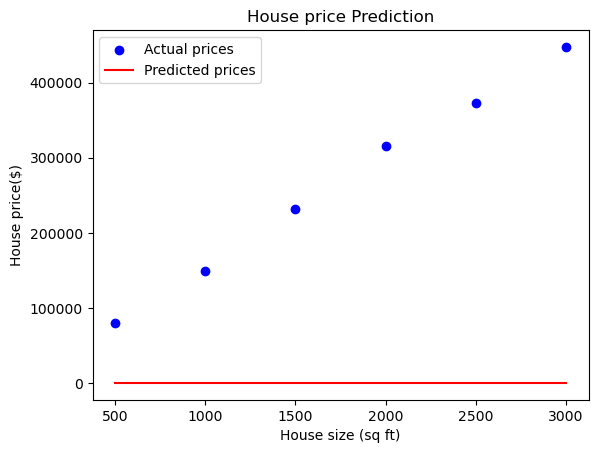

```python
# Create some synthetic data for house sizes and corresponding prices
np.random.seed(42)
X = np.array([[500], [1000], [1500], [2000], [2500], [3000]])
y = X * 150 + (np.random.randn(*X.shape) * 10000) # Random noise

nn = NeuralNetwork(input_neurons=1, hidden_neurons=1, output_neurons=1, learning_rate=0.001)
nn.train(X, y, epochs=50000)

predictions = nn.predict(X)

# Plotting the data
plt.scatter(X, y, color='blue', label ='Actual prices') # Actual prices
plt.plot(X, predictions, color ='red', label='Predicted prices') # Predicted prices
plt.xlabel('House size (sq ft)')
plt.ylabel("House price($)")
plt.title('House price Prediction')
plt.legend()
plt.show()
```

## Python I/O Operations

I/O (Input/Output) operations are essential for interacting with files, devices, or streams in Python. Python provides a robust set of tools and libraries to handle I/O efficiently. These operations primarily fall into two categories:

1. File I/O: Reading/Writing Files on FileSystem
2. Standard I/O: Interacting with standard input (stdin), standard output (stdout), and standard error (stderr).

## File I/O: Reading/Writing Files on FileSystem

- File I/O allows reading data from the files and writing data to files.
- Python provides the open() function to work with File I/O

## Open a File from FileSystem

`open(filename, mode, buffering)`

- filename: Name of the file with full path that we want to open
- mode: Operation mode (r,w,x,a,b,+)
- buffering: Controls buffers, but python controls the buffering

## File Operations Table

| Mode | Description |
| --- | --- |
| r | Read-only mode |
| w | Write mode. Creates/truncates the file |
| x | Exclusive creation. Fails if the file exists. |
| a | Append mode. Writes data at the end |
| b | Binary Mode. Used with rb, wb |
| t | Text mode (default) |
| + | Update mode (read and write) |

## Read a text file and assign the content to a python variable

```python
with open('data/text.txt','r') as text_file:
    text_content = text_file.read()

print(text_content)
```

```
My name is aayush basnet
purpose :provide the example
```

```python
import json
with open('data/text.txt','r') as text_file:
    text_content = text_file.read()
print (text_content)
with open ('data/test.json', 'r')as json_file:
    data= json.load(json_file)
print(data)
```

```
My name is aayush basnet
purpose :provide the example
{'name': 'aayush basnet', 'address': 'kathmandu', 'number': '984746373'}
```

## Read text file line by line

```python
# read text content line by line using (nextline()) and while loop
with open('data/text.txt', 'r') as text_file:
    line = text_file.readline()# read the next line
    while line:  # As long as there is a line
        print(line, end='')
        line = text_file.readline()  # Read the next line

# using for loop
with open('data/text.txt', 'r') as text_file:
    for line in text_file:
        print(line, end='')

# get all lines in a list using readlines()
with open('data/text.txt','r') as text_file:
    lines = text_file.readlines()
    print(lines)
```

```
My name is aayush basnet
purpose :provide the exampleMy name is aayush basnet
purpose :provide the example['My name is aayush basnet\n', 'purpose :provide the example']
```

## Writing to Files: Open file for writing using open('file','w')

- `write(content)` Write at once
- `writelines([line1,line2])`
- Append to files: Open file with `open(file,'a')`

```python
# Write whole content at once
with open('data/new-text-file.txt','w') as new_file:
    new_file.write('Hello World!')

#write line by line
with open('new-text-file-1.txt','w') as new_file:
    new_file.writelines(['Hello\n','World\n'])

with open('new-text-file-1.txt', 'a') as file:
    file.write('This should append on file-1.txt\n')

# Write python dict to JSON
person={
    'name':'Ram',
    'address':'Kathmandu',
    'age':32
}
with open('person.json','w')as file:
    json.dump(person,file)
```

## Python Handling Directories

The os module provides the various functions for working with Directories

Check Permissions

| Function | Description |
| --- | --- |
| `os.mkdir(path)` | Creates a directory. |
| `os.makedirs(path)` | Creates intermediate directories. |
| `os.path.exists(path)` | Checks if a path exists (file or directory). |
| `os.path.isdir(path)` | Checks if a path is a directory. |
| `os.listdir(path)` | Lists contents of a directory. |
| `os.chdir(path)` | Changes the current working directory. |
| `os.rmdir(path)` | Removes an empty directory. |
| `os.removedirs(path)` | Removes intermediate empty directories. |
| `os.rename(src, dst)` | Renames or moves a directory. |
| `os.stat(path)` | Returns the status of a file or directory (permissions, size, etc.). |
| `os.access(path, mode)` | Checks permissions of a directory. |

```python
import os

### Create New Directories
os.mkdir('test-dir')
# Creating nested directories
os.makedirs('p-dir/ch-dir')
# Check if the directory exists
if os.path.exists('test-dir'):
    print("Directory exists.")
else:
    print("Directory does not exist.")

if os.path.isdir('test-dir'):
    print("It's a directory.")
else:
    print("It's not a directory.")


# List contents of the directory
contents = os.listdir('test-dir')
print(contents)


# remove dir
os.rmdir('test-dir')


# Check if the directory is readable
if os.access('data', os.R_OK):
    print("Directory is readable.")
else:
    print("Directory is not readable.")

# Check if the directory is writable
if os.access('data', os.W_OK):
    print("Directory is writable.")
else:
    print("Directory is not writable.")


# Check if the file is executable
if os.access('main.py', os.EX_OK):
    print("Directory is writable.")
else:
    print("Directory is not writable.")
```

```
Directory exists.
It's a directory.
[]
Directory is readable.
Directory is writable.
Directory is writable.
```

```python
import os
from PIL import Image
from IPython.display import display

# Create new directories
os.mkdir('test-dir')
os.makedirs('p-dir/ch-dir')

# Check if the directory exists
if os.path.exists('test-dir'):
    print("Directory exists.")
else:
    print("Directory does not exist.")

if os.path.isdir('test-dir'):
    print("It's a directory.")
else:
    print("It's not a directory.")

# List contents of the 'data' directory and check for image files
contents = os.listdir('data')
for content in contents:
    print(content)
    # Check if the content is an image file by its extension
    if content.lower().endswith(('.png', '.jpg', '.jpeg', '.gif', '.bmp')):
        image_path = os.path.join('data', content)  # Ensure correct path
        try:
            with Image.open(image_path) as img:
                # Display the image in the Jupyter notebook
                display(img)  # This will show the image inline in Jupyter
        except Exception as e:
            print(f"Error displaying image {content}: {e}")

# Remove 'test-dir'
os.rmdir('test-dir')

# Check if the directory is readable
if os.access('data', os.R_OK):
    print("Directory is readable.")
else:
    print("Directory is not readable.")

# Check if the directory is writable
if os.access('data', os.W_OK):
    print("Directory is writable.")
else:
    print("Directory is not writable.")

# Check if the file is executable
if os.access('main.py', os.EX_OK):
    print("File is executable.")
else:
    print("File is not executable.")
```

```
Directory exists.
It's a directory.
housing.csv
marketing-sales.csv
nep-india-china-gdp.csv
nepal-economy.csv
nepal-population-ethinic-group.json
new-text-file.txt
product-data.csv
README.md
student-admission.csv
student-por.csv
student.csv
student.json
student.xlsx
test.json
text.txt
thank-you-word-cloud-concept-260nw-378218041.webp
user_data.csv
user_data.json
user_data.xlsx
Directory is readable.
Directory is writable.
File is executable.
```